# Классификация белков на семейства по их аминокислотным последовательностям

Используемые данные:

- pdb_data_seq.csv и pdb_data_no_dups.csv: https://www.kaggle.com/shahir/protein-data-set  
  (Датасет собран с RCSB PDB. Используется лишь как тренировочный набор данных)
- ly6upar.csv: известные и подтвержденные трехпетельные белки. Собран из данных Михаила Мышкина и всех результатов поиска на ncbi proteins по запросу Ly6/uPAR (https://www.ncbi.nlm.nih.gov/protein/?term=ly6%2Fupar)
- arubens_seq.csv и aplanci_seq.csv: протеом, полученный от Михаила Мышкина. Таргетный набор данных

модель взята здесь: https://www.kaggle.com/abharg16/predicting-protein-classification

### 1) Импорт библиотек и данных

```python
import os
import pandas as pd
import numpy as np
from matplotlib import pyplot as plt
import seaborn as sns
from sklearn.feature_extraction.text import CountVectorizer
from sklearn.model_selection import train_test_split
from sklearn.metrics import accuracy_score, confusion_matrix, classification_report,\
precision_recall_fscore_support, log_loss, roc_curve

from sklearn.pipeline import Pipeline
from sklearn.model_selection import cross_val_score
from sklearn.preprocessing import LabelBinarizer, label_binarize
from math import e as expon
import sklearn.metrics as metrics
from Utilities import *

from sklearn.naive_bayes import MultinomialNB
from sklearn.svm import SVC, LinearSVC
from sklearn.linear_model import LogisticRegression, SGDClassifier

model_f = pd.read_csv('input/cl_input.csv', index_col=0)
df_aru = pd.read_csv('input/arubens_seq.csv', index_col=0)
df_apl = pd.read_csv('input/aplanci_seq.csv', index_col=0)
df_ly6 = pd.read_csv('input/ly6upar.csv', index_col=0)
df_ly6['classification'] = 'Ly6/uPAR'
```

```python
model_f.head()
```

| structureId | classification | sequence |
| --- | --- | --- |
| 101M | OXYGEN TRANSPORT | MVLSEGEWQLVLHVWAKVEADVAGHGQDILIRLFKSHPETLEKFDR... |
| 102L | HYDROLASE(O-GLYCOSYL) | MNIFEMLRIDEGLRLKIYKDTEGYYTIGIGHLLTKSPSLNAAAKSE... |
| 102M | OXYGEN TRANSPORT | MVLSEGEWQLVLHVWAKVEADVAGHGQDILIRLFKSHPETLEKFDR... |
| 103L | HYDROLASE(O-GLYCOSYL) | MNIFEMLRIDEGLRLKIYKDTEGYYTIGIGHLLTKSPSLNSLDAAK... |
| 104L | HYDROLASE(O-GLYCOSYL) | MNIFEMLRIDEGLRLKIYKDTEGYYTIGIGHLLTKSPSLNAAKSAA... |

```python
df_ly6.head()
```

| genes | sequence | classification |
| --- | --- | --- |
| PF00087\|P.ariabilis | MKTLVFVVLIIVAATEIASALKCYHCGPSSKSFKDCDANGKEMDCL... | Ly6/uPAR |
| JF274292\|P.shermani | MRTTALLILLVVLFSTGEALQCNTLDGGTEECIPGIYNVCVHYKSE... | Ly6/uPAR |
| Lynx2\|N.lugens | MERAKLSFSWVIACSLLVVLCFVVHKGSSIRCYQCNSEYDPTCGDP... | Ly6/uPAR |
| PSCA\|G.gallus | MKVFFILLLAAILCTDPGSSLQCYSCKTKLSNSNCQATMNCKENEM... | Ly6/uPAR |
| ACVR1\|H.sapiens | MVDGVMILPVLIMIALPSPSMEDEKPKVNPKLYMCVCEGLSCGNED... | Ly6/uPAR |

pd.options.display.max_rows=1200

```
(66,)
```

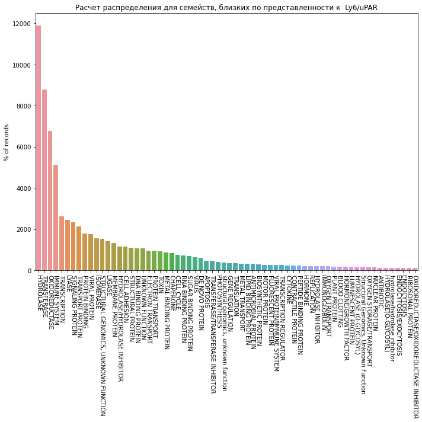

```python
cou = model_f.classification.value_counts()
cou = cou[(cou > 100)]
print(cou.shape)

# Рисуем распределение
fig , ax = plt.subplots()
fig.set_size_inches(10, 10)
g = sns.barplot(x=cou.index, y=cou)
g.set_xticklabels(cou.index, rotation=-90)
plt.title('Расчет распределения для семейств, близких по представленности к  Ly6/uPAR')
plt.ylabel('% of records')
plt.tight_layout()
plt.show()
```

```python
x = df_ly6.shape[0] / cou.sum()
cou = (cou * x).apply(lambda x: round(x) + 1)

df_test = pd.DataFrame()
for i, j in zip(cou, cou.index):
    df_test = pd.concat([df_test, find_proteins(model_f, j, i, 10)])

X_train, X_test, y_train, y_test = train_test(df_test, df_ly6)
```

```python
X_train.shape[0] + X_test.shape[0] - df_test.shape[0]
```

```
227
```

```python
# Тест по случайным величинам
precision_r = []
recall_r = []
f1_score_r = []
res = y_test.copy()
for i in range(100):
    np.random.shuffle(res)
    tmp = precision_recall_fscore_support(y_pred=res, y_true=y_test, labels=['Ly6/uPAR'])
    precision_r += [tmp[0][0]]
    recall_r += [tmp[1][0]]
    f1_score_r += [tmp[2][0]]

print('random precison = ', np.mean(precision_r))
print('random recall = ', np.mean(recall_r))
print('random f1 score = ', np.mean(f1_score_r))
```

```
random precison =  0.07436170212765958
random recall =  0.07436170212765958
random f1 score =  0.07436170212765958
```

```python
presc = {}
precision_SVC, recall_SVC, accuracy_SVC, f1_score_SVC, indexes_SVC = [], [], [], [], []
precision_NB, recall_NB, accuracy_NB, f1_score_NB, indexes_NB = [], [], [], [], []

log_loss_SVC, log_loss_NB = [], []

for i in range(2, 13):
    for j in range(i, 13):

        SVC_pipeline = Pipeline(steps=[
            ('tokenizer', CountVectorizer(analyzer = 'char_wb', ngram_range = (i, j))),
            ('model', LinearSVC(max_iter=100000, random_state=1, class_weight='balanced'))
            ])
        NB_pipeline = Pipeline(steps=[
            ('tokenizer', CountVectorizer(analyzer = 'char_wb', ngram_range = (i, j))),
            ('model', MultinomialNB())
            ])


        SVC_pipeline.fit(X_train, y_train)
        NB_pipeline.fit(X_train, y_train)

        SVC_pred = SVC_pipeline.predict(X_test)
        NB_pred = NB_pipeline.predict(X_test)

        accr_SVC = accuracy_score(SVC_pred, y_test)
        accr_NB = accuracy_score(NB_pred, y_test)

        f1_SVC = precision_recall_fscore_support(y_pred=SVC_pred, y_true=y_test, labels=['Ly6/uPAR'])
        f1_NB = precision_recall_fscore_support(y_pred=NB_pred, y_true=y_test, labels=['Ly6/uPAR'])

        loss_SVC = log_loss(y_pred=label_binarize(SVC_pred, classes=['NORES', 'Ly6/uPAR']),
                                y_true=label_binarize(y_test, classes=['NORES', 'Ly6/uPAR']))
        loss_NB = log_loss(y_pred=label_binarize(NB_pred, classes=['NORES', 'Ly6/uPAR']),
                               y_true=label_binarize(y_test, classes=['NORES', 'Ly6/uPAR']))

        print(i, j)
        print('accuracy SVC = ', accr_SVC)
        print('accuracy NB = ', accr_NB)
#         print(f"precison = {f1[0][0]}\nrecall = {f1[1][0]}\n")
        print('logistic Loss for SVC', loss_SVC)
        print('logistic Loss for NB', loss_NB)

        precision_SVC.append(f1_SVC[0][0]), recall_SVC.append(f1_SVC[1][0]), f1_score_SVC.append(f1_SVC[2][0])
        accuracy_SVC.append(accr_SVC), indexes_SVC.append((i, j)), log_loss_SVC.append(loss_SVC)

        precision_NB.append(f1_NB[0][0]), recall_NB.append(f1_NB[1][0]), f1_score_NB.append(f1_NB[2][0])
        accuracy_NB.append(accr_NB), indexes_NB.append((i, j)), log_loss_NB.append(loss_NB)
```

```
2 2
accuracy SVC =  0.9747235387045814
accuracy NB =  0.9202211690363349
logistic Loss for SVC 0.8730262554531877
logistic Loss for NB 2.755518152339974
2 3
accuracy SVC =  0.9834123222748815
accuracy NB =  0.9320695102685624
logistic Loss for SVC 0.5729212498264427
logistic Loss for NB 2.34628083837272
2 4
accuracy SVC =  0.9834123222748815
accuracy NB =  0.9636650868878357
logistic Loss for SVC 0.5729206182328959
logistic Loss for NB 1.254965965683739
2 5
accuracy SVC =  0.9834123222748815
accuracy NB =  0.9447077409162717
logistic Loss for SVC 0.5729206182328959
logistic Loss for NB 1.9097269728623607
2 6
accuracy SVC =  0.9834123222748815
accuracy NB =  0.9462875197472354
logistic Loss for SVC 0.5729199866393492
logistic Loss for NB 1.8551639766598405
2 7
accuracy SVC =  0.981042654028436
accuracy NB =  0.9518167456556083
logistic Loss for SVC 0.6547647967399036
logistic Loss for NB 1.6641912793736044
2 8
accuracy SVC =  0.9786729857819905
accuracy NB =  0.9518167456556083
logistic Loss for SVC 0.7366102384340047
logistic Loss for NB 1.6641912793736044
2 9
accuracy SVC =  0.9770932069510269
accuracy NB =  0.95260663507109
logistic Loss for SVC 0.7911732346365254
logistic Loss for NB 1.6369094654755705
```

[output cut: 275 more lines]

```
11 11
accuracy SVC =  0.9454976303317536
accuracy NB =  0.9628751974723538
logistic Loss for SVC 1.8824457905578744
logistic Loss for NB 1.2822458848011322
11 12
accuracy SVC =  0.9447077409162717
accuracy NB =  0.9628751974723538
logistic Loss for SVC 1.9097276044559082
logistic Loss for NB 1.2822458848011322
12 12
accuracy SVC =  0.9447077409162717
accuracy NB =  0.9612954186413902
logistic Loss for SVC 1.9097276044559082
logistic Loss for NB 1.3368095125971997
```

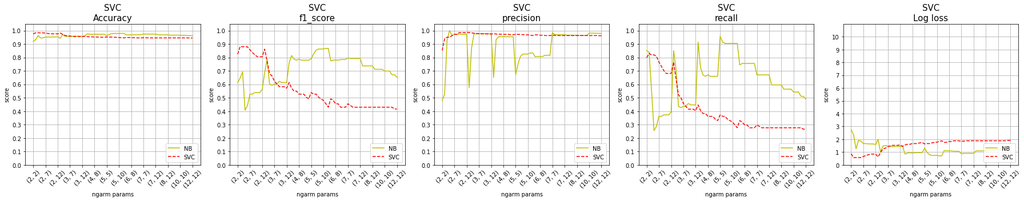

```python
fig, ax = plt.subplots(1, 5, figsize=(25, 5), tight_layout=True)

metrs = [accuracy_NB, f1_score_NB, precision_NB, recall_NB, log_loss_NB,
         accuracy_SVC, f1_score_SVC, precision_SVC, recall_SVC, log_loss_SVC]

labels = ['NB \nAccuracy', 'NB \nf1_score', 'NB \nprecision', 'NB \nrecall', 'NB \nLog loss',
          'SVC\nAccuracy', 'SVC\nf1_score', 'SVC\nprecision', 'SVC\nrecall', 'SVC\nLog loss']
jls = [0, 1, 2, 3, 4] * 2
inds = [indexes_NB]*5 + [indexes_SVC]*5
lines = ['y'] * 5 + ['r--'] * 5


for j, y, label, index, line in zip(jls, metrs, labels, inds, lines):
    ax_plotter(ax, j, y, label, index, line)

for j in range(5):
    ax[j].grid()
    ax[j].legend(loc='lower right')

plt.tight_layout()
fig.savefig('NB_vs_SVC.png', facecolor='white')
plt.show()
```

```python
print(' ' * 5, 'precision', 'recall', 'accuracy', 'log loss', 'f1_score', sep='    ')
print('SVC', indexes_SVC[precision_SVC.index(max(precision_SVC))],
      indexes_SVC[recall_SVC.index(max(recall_SVC))],
      indexes_SVC[accuracy_SVC.index(max(accuracy_SVC))],
      indexes_SVC[log_loss_SVC.index(max(log_loss_SVC))],
      indexes_SVC[f1_score_SVC.index(max(f1_score_SVC))], sep=' ' * 6
     )
print('NB ', indexes_NB[precision_NB.index(max(precision_NB))],
      indexes_NB[recall_NB.index(max(recall_NB))],
      indexes_NB[accuracy_NB.index(max(accuracy_NB))],
      indexes_NB[log_loss_NB.index(max(log_loss_NB))],
      indexes_NB[f1_score_NB.index(max(f1_score_NB))], sep=' ' * 6
     )

svc_i, svc_j = indexes_SVC[f1_score_SVC.index(max(f1_score_SVC))]
NB_i, NB_j = indexes_NB[f1_score_NB.index(max(f1_score_NB))]
(svc_i, svc_j), (NB_i, NB_j)
```

```
         precision    recall    accuracy    log loss    f1_score
SVC      (3, 3)      (2, 3)      (2, 3)      (11, 12)      (2, 3)
NB       (2, 5)      (5, 5)      (5, 11)      (2, 2)      (5, 11)
```

```
((2, 3), (5, 11))
```

```python
print(f'len of NB {(svc_i, svc_j)} = ', CountVectorizer(analyzer = 'char_wb', ngram_range = (svc_i, svc_j)).fit_transform(X_train).shape)
print(f'len of SVC {(NB_i, NB_j)} = ', CountVectorizer(analyzer = 'char_wb', ngram_range = (NB_i, NB_j)).fit_transform(X_train).shape)
```

```
len of NB (2, 3) =  (1891, 8958)
len of SVC (5, 11) =  (1891, 2783900)
```

```python
X_train, X_test, y_train, y_test = train_test(df_test, df_ly6)
X_train.shape, X_test.shape
```

```
((1891,), (1266,))
```

```python
# Final model scoring
# svc_i, svc_j = 3, 3
SVC_pipeline = Pipeline(steps=[
            ('tokenizer', CountVectorizer(analyzer = 'char_wb', ngram_range = (svc_i, svc_j))),
            ('model', LinearSVC(max_iter=100000, random_state=1, class_weight='balanced'))
            ])
SVC_pipeline.fit(X_train, y_train)

SVC_pred = SVC_pipeline.predict(X_test)
accr_SVC = accuracy_score(SVC_pred, y_test)
f1_SVC = precision_recall_fscore_support(y_pred=SVC_pred, y_true=y_test, labels=['Ly6/uPAR'])
print('accuracy = ', accr_SVC)
print(f'precison = {f1_SVC[0][0]}\nrecall = {f1_SVC[1][0]}\n')# Вывод метрик отчета классификации
```

```
accuracy =  0.9818325434439179
precison = 0.9863013698630136
recall = 0.7659574468085106
```

```python
# Final model scoring
NB_pipeline = Pipeline(steps=[
            ('tokenizer', CountVectorizer(analyzer = 'char_wb', ngram_range = (NB_i, NB_j))),
            ('model', MultinomialNB())
            ])
NB_pipeline.fit(X_train, y_train)

NB_pred = NB_pipeline.predict(X_test)
accr_NB = accuracy_score(NB_pred, y_test)
f1_NB = precision_recall_fscore_support(y_pred=NB_pred, y_true=y_test, labels=['Ly6/uPAR'])
print('accuracy = ', accr_NB)
print(f'precison = {f1_NB[0][0]}\nrecall = {f1_NB[1][0]}\n')# Вывод метрик отчета классификации
```

```
accuracy =  0.9794628751974723
precison = 0.8333333333333334
recall = 0.9042553191489362
```

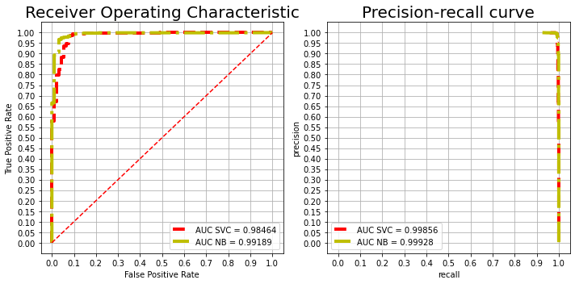

```python
fig, ax = plt.subplots(1, 2, figsize=(10, 5), tight_layout=True)


# find index of Ly6/uPAR class
x = 0
for i in enumerate(NB_pipeline.classes_):
    x = i[0] if i[1] == 'Ly6/uPAR' else x

# calculate the fpr and tpr for all thresholds of the classification
preds_SVC = SVC_pipeline.decision_function(X_test)
preds_NB = NB_pipeline.predict_proba(X_test)[:, 1]

y_true = label_binarize(y_test, classes=['Ly6/uPAR', 'NORES'])

fpr_SVC, tpr_SVC, threshold_SVC = metrics.roc_curve(y_true, preds_SVC)
roc_auc_SVC = metrics.roc_auc_score(y_true, preds_SVC, average='weighted')

fpr_NB, tpr_NB, threshold_NB = metrics.roc_curve(y_true, preds_NB)
roc_auc_NB = metrics.roc_auc_score(y_true, preds_NB, average='weighted')

# Receiver Operating Characteristic
ax[0].set_title('Receiver Operating Characteristic', size=20)
ax[0].plot(fpr_SVC, tpr_SVC, 'r--', label = 'AUC SVC = %.5f' % roc_auc_SVC, linewidth=4)
ax[0].plot(fpr_NB, tpr_NB, '-.y', label = 'AUC NB = %.5f' % roc_auc_NB, linewidth=4)
ax[0].legend(loc = 'lower right')
ax[0].plot([0, 1], [0, 1],'r--')
ax[0].set_xlim([-0.05, 1.05])
ax[0].set_ylim([-0.05, 1.05])
ax[0].set_yticks(np.arange(0, 1.01, 0.05))
ax[0].set_xticks(np.arange(0, 1.01, 0.1))
ax[0].set_ylabel('True Positive Rate')
ax[0].set_xlabel('False Positive Rate')
ax[0].grid()

# Precision-recall curve
rec_SVC, pre_SVC, threshold = metrics.precision_recall_curve(y_true, preds_SVC)
pr_rec_SVC = metrics.average_precision_score(y_true, preds_SVC, average='weighted')

rec_NB, pre_NB, threshold = metrics.precision_recall_curve(y_true, preds_NB)
pr_rec_NB = metrics.average_precision_score(y_true, preds_NB, average='weighted')


ax[1].plot(rec_SVC, pre_SVC, 'r--', label='AUC SVC = %.5f' % pr_rec_SVC, linewidth=4)
ax[1].plot(rec_NB, pre_NB, '-.y', label='AUC NB = %.5f' % pr_rec_NB, linewidth=4)
ax[1].legend(loc = 'lower left')
ax[1].set_title('Precision-recall curve', size=20)
ax[1].set_ylabel('precision')
ax[1].set_xlabel('recall')
ax[1].set_xlim([-0.05, 1.05])
ax[1].set_ylim([-0.05, 1.05])
ax[1].set_xticks(np.arange(0, 1.01, 0.1))
ax[1].set_yticks(np.arange(0, 1.01, 0.05))
ax[1].grid()
plt.tight_layout()
plt.show()
```

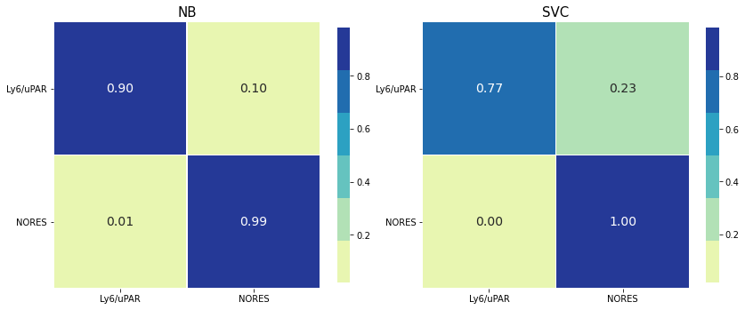

```python
# Построение матрицы ошибок
conf_mat_m_NB = confusion_matrix(y_true=y_test, y_pred=NB_pred, labels=['Ly6/uPAR', 'NORES']
                              , normalize='true')
conf_mat_m_SVC = confusion_matrix(y_true=y_test, y_pred=SVC_pred, labels=['Ly6/uPAR', 'NORES']
                              , normalize='true')

# Строим HeatMap
fig , ax = plt.subplots(1, 2, figsize=(12, 6), tight_layout=True)

m = sns.heatmap(conf_mat_m_NB, annot=True, fmt='.2f', linewidths=.3,
                annot_kws={"size": 14}, ax=ax[0],
                square=True, robust=True,
                cmap=sns.color_palette("YlGnBu"), cbar_kws={'shrink': 0.7}
                )
g = sns.heatmap(conf_mat_m_SVC, annot=True, fmt='.2f', linewidths=.3,
                annot_kws={"size": 14}, ax=ax[1],
                square=True, robust=True,
                cmap=sns.color_palette("YlGnBu"), cbar_kws={'shrink': 0.7}
                )
m.set_title('NB', size=15)
g.set_title('SVC', size=15)
m.set_xticklabels(['Ly6/uPAR', 'NORES']) #, rotation=45)
m.set_yticklabels(['Ly6/uPAR', 'NORES'], rotation=360)
g.set_xticklabels(['Ly6/uPAR', 'NORES']) #, rotation=45)
g.set_yticklabels(['Ly6/uPAR', 'NORES'], rotation=360)

plt.show()
```

```python
# Вывод метрик отчета классификации
print('NB\n', classification_report(y_test, NB_pred), '\n')
print('SVC\n', classification_report(y_test, SVC_pred))
```

```
NB
               precision    recall  f1-score   support

    Ly6/uPAR       0.83      0.90      0.87        94
       NORES       0.99      0.99      0.99      1172

    accuracy                           0.98      1266
   macro avg       0.91      0.94      0.93      1266
weighted avg       0.98      0.98      0.98      1266


SVC
               precision    recall  f1-score   support

    Ly6/uPAR       0.99      0.77      0.86        94
       NORES       0.98      1.00      0.99      1172

    accuracy                           0.98      1266
   macro avg       0.98      0.88      0.93      1266
weighted avg       0.98      0.98      0.98      1266
```